# Final Project

## Introduction

I am running analysis on spotify song data. This database downloaded from Kagle link: https://www.kaggle.com/pepepython/spotify-huge-database-daily-charts-over-3-years. The data is a amalgomation of Spotify's Rancking Charts for 3 years. The charts are by countries so a song can appear multiple times if it ranked in many countries charts. Each row is a equivlaent to a song that appeared on the chart. The rows contain many values but ones I want to focus on are country that contains the chart, the song name, artist, popularity of the song, if it was a single or part of an album, genre, aritst, release date, followers, danceability, Energy, Key, Loudness, Mode, Speechiness, Acousticness, Instrumentalness, Liveness, Valence, Temp, and Duration. For more information on these stats, head to the dataset link. The popularity was calculated by the duration the song stayed on the chart and what rankings it attained. The music features columns are calculated by spotify in there spotipy utility. For more information about spotipy, use this link: https://spotipy.readthedocs.io/en/2.18.0/.

I am interested in many questions that this dataset could procide insight on but I want to know specifically what makes a song popular. i also want to explore how music has change over the years. Using these values I hope to explore this train of thought.

## Set Up

Here are the packages used in this tutorial. They are the same ones we have been using over the course. They are for cleaning, storing, modifying, and analysing the data

```python
import pandas as pd
import numpy as np
import seaborn as sns
import matplotlib.pyplot as plt
from statsmodels.formula.api import logit
from statsmodels.api import OLS
import re

from sklearn import preprocessing
from sklearn import metrics
from sklearn.metrics import confusion_matrix
from sklearn.metrics import precision_score, recall_score, f1_score
from sklearn.linear_model import LogisticRegression
from sklearn.linear_model import LinearRegression
from sklearn.model_selection import cross_val_predict

from sklearn import linear_model,datasets
from sklearn.model_selection import train_test_split

from sklearn import svm
from sklearn.model_selection import cross_val_score

import sklearn.ensemble
import sklearn.model_selection
import sklearn.metrics
import sklearn.linear_model
```

## Loading the Data

I will load the data I got from the csv into a dataframe. This dataframe has a lot of columns because it has columns for true/false values in the other cloumns. For Example, there is an Argentina column and it marks if the chart used for ranking the song was Argentina's. I wont load these coloumns so so i dont waste time. The True/False columns start after column 30 so we will take the first 27 columns

```python
colrange = [i for i in range(0,27)]
```

```python
#dt = {'Country':object,'Popularity':float,'Artist':object,'Album/Single':object,'Artist_followers':float,'Explicit':bool,'Release_date':object,'danceability':float,'energy':float,'key':float,'loudness':float,'mode':float,'speechiness':float,'acoustics':float,'instrumentalness':float,'liveliness':float,'valence':float,'tempo':float,'duration_ms':float,'time_signature':float,'Genre_new':object}
```

```python
spotify = pd.read_csv("Final Database.csv", low_memory=False,usecols=colrange)
```

```python
spotify.head()
```

|  | Country | Uri | Popularity | Title | Artist | Album/Single | Genre | Artist_followers | Explicit | Album | ... | mode | speechiness | acoustics | instrumentalness | liveliness | valence | tempo | duration_ms | time_signature | Genre_new |
| --- | --- | --- | --- | --- | --- | --- | --- | --- | --- | --- | --- | --- | --- | --- | --- | --- | --- | --- | --- | --- | --- |
| 0 | Global | https://open.spotify.com/track/6FyRXC8tJUh863J... | 31833.95 | adan y eva | Paulo Londra | single | argentine hip hop | 11427104.0 | False | Adan y Eva | ... | 1 | 0.336 | 0.32299999999999995 | 0.0 | 0.0676 | 0.72 | 171.993 | 258639 | 4 | hip hop |
| 1 | USA | https://open.spotify.com/track/6FyRXC8tJUh863J... | 8.00 | adan y eva | Paulo Londra | single | argentine hip hop | 11427104.0 | False | Adan y Eva | ... | 1 | 0.336 | 0.32299999999999995 | 0.0 | 0.0676 | 0.72 | 171.993 | 258639 | 4 | hip hop |
| 2 | Argentina | https://open.spotify.com/track/6FyRXC8tJUh863J... | 76924.40 | adan y eva | Paulo Londra | single | argentine hip hop | 11427104.0 | False | Adan y Eva | ... | 1 | 0.336 | 0.32299999999999995 | 0.0 | 0.0676 | 0.72 | 171.993 | 258639 | 4 | hip hop |
| 3 | Belgium | https://open.spotify.com/track/6FyRXC8tJUh863J... | 849.60 | adan y eva | Paulo Londra | single | argentine hip hop | 11427104.0 | False | Adan y Eva | ... | 1 | 0.336 | 0.32299999999999995 | 0.0 | 0.0676 | 0.72 | 171.993 | 258639 | 4 | hip hop |
| 4 | Switzerland | https://open.spotify.com/track/6FyRXC8tJUh863J... | 20739.10 | adan y eva | Paulo Londra | single | argentine hip hop | 11427104.0 | False | Adan y Eva | ... | 1 | 0.336 | 0.32299999999999995 | 0.0 | 0.0676 | 0.72 | 171.993 | 258639 | 4 | hip hop |

5 rows × 27 columns

## Tidying the Data

I will not make any use of the uri column as it does not pertain to any data. There are two genre columns. There are columns that list the track number in album and the number of tracks in its album, and its explicit label, which I do not deem useful for the popularity analysis I want to run. The genre_new column is the dataset's author improved genre column. Therefore, I will also not be using genre column. I will remove these columns to tidy the data.

```python
spotify1 = spotify.drop(['Uri', 'Genre', 'Track_number', 'Tracks_in_album'], axis=1)
```

I also want to simplify the track's categorical data that describes what the song is. These include song title, album, and artist. I want to create a new column that will create an indetifier for the track so we can quickly see which two songs are the same. The ID will just be an conatination of these columns. I will keep the artist column in case I want to run data on the `Artist_following` column. I will get rid of album and title.

```python
spotify1['title_artist_album'] = spotify1['Title'] +"_"+ spotify1['Artist'] +"_"+ spotify1['Album']
spotify1 = spotify1.drop(['Title', 'Album'], axis=1)
```

```python
spotify1.head()
```

|  | Country | Popularity | Artist | Album/Single | Artist_followers | Explicit | Release_date | danceability | energy | key | ... | speechiness | acoustics | instrumentalness | liveliness | valence | tempo | duration_ms | time_signature | Genre_new | title_artist_album |
| --- | --- | --- | --- | --- | --- | --- | --- | --- | --- | --- | --- | --- | --- | --- | --- | --- | --- | --- | --- | --- | --- |
| 0 | Global | 31833.95 | Paulo Londra | single | 11427104.0 | False | 2018-11-05 | 0.767 | 0.7090000000000001 | 1 | ... | 0.336 | 0.32299999999999995 | 0.0 | 0.0676 | 0.72 | 171.993 | 258639 | 4 | hip hop | adan y eva_Paulo Londra_Adan y Eva |
| 1 | USA | 8.00 | Paulo Londra | single | 11427104.0 | False | 2018-11-05 | 0.767 | 0.7090000000000001 | 1 | ... | 0.336 | 0.32299999999999995 | 0.0 | 0.0676 | 0.72 | 171.993 | 258639 | 4 | hip hop | adan y eva_Paulo Londra_Adan y Eva |
| 2 | Argentina | 76924.40 | Paulo Londra | single | 11427104.0 | False | 2018-11-05 | 0.767 | 0.7090000000000001 | 1 | ... | 0.336 | 0.32299999999999995 | 0.0 | 0.0676 | 0.72 | 171.993 | 258639 | 4 | hip hop | adan y eva_Paulo Londra_Adan y Eva |
| 3 | Belgium | 849.60 | Paulo Londra | single | 11427104.0 | False | 2018-11-05 | 0.767 | 0.7090000000000001 | 1 | ... | 0.336 | 0.32299999999999995 | 0.0 | 0.0676 | 0.72 | 171.993 | 258639 | 4 | hip hop | adan y eva_Paulo Londra_Adan y Eva |
| 4 | Switzerland | 20739.10 | Paulo Londra | single | 11427104.0 | False | 2018-11-05 | 0.767 | 0.7090000000000001 | 1 | ... | 0.336 | 0.32299999999999995 | 0.0 | 0.0676 | 0.72 | 171.993 | 258639 | 4 | hip hop | adan y eva_Paulo Londra_Adan y Eva |

5 rows × 22 columns

```python
spotify1.shape
```

```
(170633, 22)
```

```python
spotify1[spotify1.values == 'n\x07']['title_artist_album'].value_counts().size
```

```
4
```

There are some rows that contain missing data. Missing data is represented by "n\x07". As you can see from the code above, there are only 4 tracks that have missing data, so I will delete them since it wont be significant to lose 4 tracks.

```python
spotify1 = spotify1.replace('n\x07',np.NaN)
spotify1 = spotify1.dropna()
```

```python
spotify1.shape
```

```
(170573, 22)
```

```python
spotify1.dtypes
```

```
Country                object
Popularity            float64
Artist                 object
Album/Single           object
Artist_followers       object
Explicit               object
Release_date           object
danceability           object
energy                 object
key                    object
loudness               object
mode                   object
speechiness            object
acoustics              object
instrumentalness       object
liveliness             object
valence                object
tempo                  object
duration_ms            object
time_signature         object
Genre_new              object
title_artist_album     object
dtype: object
```

You can see for the dtypes we have a lot of object types. Many of these columns should actually be numerical, but the CSV read it as an object. We will fix this by applying a function that turns the columns we want to numerics.

```python
numerical_features = ['Artist_followers','key','loudness','mode','danceability', 'energy', 'instrumentalness', 'valence', 'liveliness', 'speechiness', 'acoustics',
                      'speechiness', 'acoustics', 'instrumentalness', 'liveliness', 'valence', 'tempo', 'duration_ms',
                      'time_signature']
# convert just numerical columns to numerics
spotify1[numerical_features] = spotify1[numerical_features].apply(pd.to_numeric)

#convert explicit column to integer represting 0: False, 1: True
# singles will be encoded as 0, and songs part of an album encoded as 1
d = {'True': 1, 'False': 0, 'single':0, 'album':1, 'compilation':1}
spotify1['Explicit'] = spotify1['Explicit'].map(d)
spotify1['Album/Single'] = spotify1['Album/Single'].map(d)
#rename column Album/Single so we dont have to worry about the /
spotify1 = spotify1.rename(columns={'Album/Single':'is_single'})
```

Since I want to have analysis on how music changes, I created a `year` column based off the `ReleaseDate` column.

```python
spotify1['year'] = spotify1['Release_date'].str[:4].astype(int)
```

```python
spotify1.head()
```

|  | Country | Popularity | Artist | is_single | Artist_followers | Explicit | Release_date | danceability | energy | key | ... | acoustics | instrumentalness | liveliness | valence | tempo | duration_ms | time_signature | Genre_new | title_artist_album | year |
| --- | --- | --- | --- | --- | --- | --- | --- | --- | --- | --- | --- | --- | --- | --- | --- | --- | --- | --- | --- | --- | --- |
| 0 | Global | 31833.95 | Paulo Londra | 0 | 11427104.0 | 0 | 2018-11-05 | 0.767 | 0.709 | 1 | ... | 0.323 | 0.0 | 0.0676 | 0.72 | 171.993 | 258639 | 4 | hip hop | adan y eva_Paulo Londra_Adan y Eva | 2018 |
| 1 | USA | 8.00 | Paulo Londra | 0 | 11427104.0 | 0 | 2018-11-05 | 0.767 | 0.709 | 1 | ... | 0.323 | 0.0 | 0.0676 | 0.72 | 171.993 | 258639 | 4 | hip hop | adan y eva_Paulo Londra_Adan y Eva | 2018 |
| 2 | Argentina | 76924.40 | Paulo Londra | 0 | 11427104.0 | 0 | 2018-11-05 | 0.767 | 0.709 | 1 | ... | 0.323 | 0.0 | 0.0676 | 0.72 | 171.993 | 258639 | 4 | hip hop | adan y eva_Paulo Londra_Adan y Eva | 2018 |
| 3 | Belgium | 849.60 | Paulo Londra | 0 | 11427104.0 | 0 | 2018-11-05 | 0.767 | 0.709 | 1 | ... | 0.323 | 0.0 | 0.0676 | 0.72 | 171.993 | 258639 | 4 | hip hop | adan y eva_Paulo Londra_Adan y Eva | 2018 |
| 4 | Switzerland | 20739.10 | Paulo Londra | 0 | 11427104.0 | 0 | 2018-11-05 | 0.767 | 0.709 | 1 | ... | 0.323 | 0.0 | 0.0676 | 0.72 | 171.993 | 258639 | 4 | hip hop | adan y eva_Paulo Londra_Adan y Eva | 2018 |

5 rows × 23 columns

```python
spotify1.dtypes
```

```
Country                object
Popularity            float64
Artist                 object
is_single               int64
Artist_followers      float64
Explicit                int64
Release_date           object
danceability          float64
energy                float64
key                     int64
loudness              float64
mode                    int64
speechiness           float64
acoustics             float64
instrumentalness      float64
liveliness            float64
valence               float64
tempo                 float64
duration_ms             int64
time_signature          int64
Genre_new              object
title_artist_album     object
year                    int64
dtype: object
```

Now you can see we have the correct types for each column. However, If i want to include the categorical columns, I will also need to turn these to numerics. We will use the label Encoder in the sklearn package to add columns that correspond to numerical data for selected columns

```python
categorical_features = ['Artist','Genre_new','Country']
le = sklearn.preprocessing.LabelEncoder()

for column in categorical_features:
    spotify1['num_'+column] = le.fit_transform(spotify1[column])
```

## EDA

EDA, or exploratory analysis means that we are trying to provide visualization to the data so we can gain some insight on it. For more infromation on types of EDA you can use, follow this link: https://towardsdatascience.com/exploratory-data-analysis-eda-python-87178e35b14

We will first be Using a correlation matrix heat map to analyse correlation between columns. This will help us identify what columns we want to use for the popularity analysis. For more information on how to customisize your heatmap use these links: https://towardsdatascience.com/annotated-heatmaps-in-5-simple-steps-cc2a0660a27d, https://heartbeat.fritz.ai/seaborn-heatmaps-13-ways-to-customize-correlation-matrix-visualizations-f1c49c816f07 .

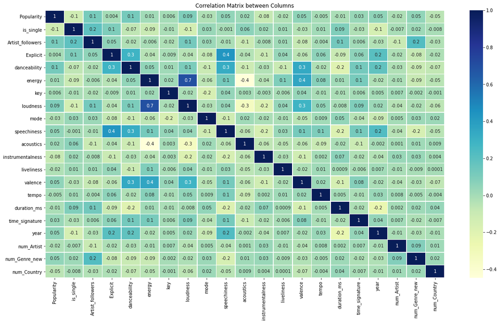

```python
#Correlation Matrix
plt.subplots(figsize = (20,11))
g = sns.heatmap(spotify1.corr("spearman"), annot = True, cmap = "YlGnBu", fmt = '.1g', linewidths=.5,)

g.set_title("Correlation Matrix between Columns")
```

Judging from this plot, none of the variables seem to be highly correlated with popularity. The two best predictors of popularity are whether its a single, the artist's followers, danceability, and loudness with around 0.1 correlation.

From the plot you can see that there is a little better results with year. Explicitness, danceability, and speechiness all have a correlation of 0.2.

The most high cordinated columns are loudness and energy. This means as songs get more loud they increase energy.

Another interesting question is what makes a song danceable? From this it seems it is valence, speechiness, and explicitness, since they have the highest correlation to the dancibility column.

I want to look at just Global charts data if we get similar results

```python
Gspotify = spotify1.loc[spotify1['Country'] == "Global"]
Gspotify.head()
```

|  | Country | Popularity | Artist | is_single | Artist_followers | Explicit | Release_date | danceability | energy | key | ... | valence | tempo | duration_ms | time_signature | Genre_new | title_artist_album | year | num_Artist | num_Genre_new | num_Country |
| --- | --- | --- | --- | --- | --- | --- | --- | --- | --- | --- | --- | --- | --- | --- | --- | --- | --- | --- | --- | --- | --- |
| 0 | Global | 31833.95 | Paulo Londra | 0 | 11427104.0 | 0 | 2018-11-05 | 0.767 | 0.709 | 1 | ... | 0.720 | 171.993 | 258639 | 4 | hip hop | adan y eva_Paulo Londra_Adan y Eva | 2018 | 18267 | 6 | 14 |
| 16 | Global | 418.00 | The Chainsmokers - Louane | 1 | 16931568.0 | 0 | 2017-04-07 | 0.572 | 0.530 | 6 | ... | 0.120 | 170.138 | 217613 | 4 | pop | it wont kill ya_The Chainsmokers - Louane_Memo... | 2017 | 22335 | 14 | 14 |
| 39 | Global | 56.00 | Kesha | 0 | 5910376.0 | 1 | 2017-08-03 | 0.488 | 0.538 | 6 | ... | 0.380 | 67.037 | 205600 | 4 | pop | hymn_Kesha_Hymn | 2017 | 12214 | 14 | 14 |
| 58 | Global | 78.40 | Foo Fighters | 1 | 8092392.0 | 0 | 2017-09-15 | 0.515 | 0.917 | 1 | ... | 0.409 | 121.988 | 266187 | 4 | metal | arrows_Foo Fighters_Concrete and Gold | 2017 | 7808 | 12 | 14 |
| 80 | Global | 244.95 | Linkin Park | 1 | 17132813.0 | 0 | 2017-05-19 | 0.593 | 0.712 | 2 | ... | 0.473 | 124.013 | 231307 | 4 | metal | talking to myself_Linkin Park_One More Light | 2017 | 13774 | 12 | 14 |

5 rows × 26 columns

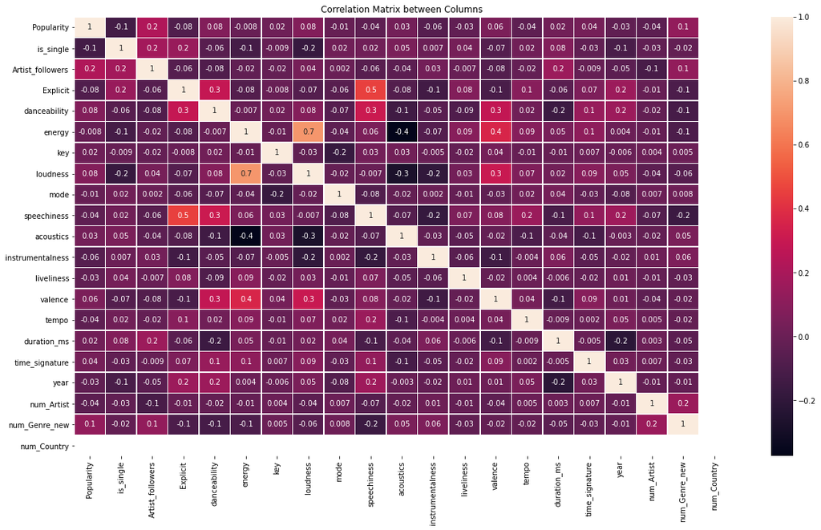

```python
#Correlation Matrix
plt.subplots(figsize = (20,11))
g = sns.heatmap(Gspotify.corr("spearman"), annot = True, fmt = '.1g', linewidths=.5,)

g.set_title("Correlation Matrix between Columns")
```

From the plot you can see that there is a little better results with year. Explicitness, danceability, and speechiness all have a correlation of 0.2.

The most high cordinated columns are loudness and energy. This means as songs get more loud they increase energy.

Another interesting question is what makes a song danceable? From this it seems it is valence, speechiness, and explicitness.

```python
timeSpotify = spotify1[['year','danceability', 'energy','speechiness','acoustics','instrumentalness', 'liveliness','valence']]
timeSpotify = timeSpotify.groupby('year').mean()
timeSpotify = timeSpotify.reset_index()
timeSpotify.head()
```

|  | year | danceability | energy | speechiness | acoustics | instrumentalness | liveliness | valence |
| --- | --- | --- | --- | --- | --- | --- | --- | --- |
| 0 | 1899 | 0.281000 | 0.343000 | 0.031100 | 0.829000 | 0.966000 | 0.254000 | 0.382000 |
| 1 | 1900 | 0.549000 | 0.324000 | 0.065300 | 0.755000 | 0.000001 | 0.487000 | 0.589000 |
| 2 | 1929 | 0.227000 | 0.446000 | 0.032000 | 0.851000 | 0.009120 | 0.322000 | 0.119000 |
| 3 | 1939 | 0.480000 | 0.293000 | 0.061233 | 0.924000 | 0.163340 | 0.205767 | 0.579000 |
| 4 | 1942 | 0.319323 | 0.157032 | 0.037819 | 0.673677 | 0.411742 | 0.328903 | 0.263355 |

```python
# timeSpotify = spotify1[['decade','danceability', 'energy','speechiness','acoustics','instrumentalness', 'liveliness','valence']]
# timeSpotify = timeSpotify.groupby('decade').mean()
# timeSpotify = timeSpotify.reset_index()
```

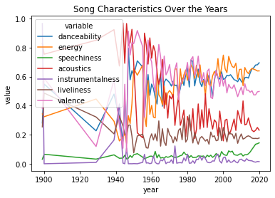

```python
sns.lineplot(data=pd.melt(timeSpotify, ['year']), x='year', y='value', hue='variable').set_title('Song Characteristics Over the Years');
```

You can see that acoustics started out high and has decreased. instrumentalmess, liveliness and speechiness have remained generally the same. Energy and danceability,have increased slightly.

```python
#variables we want in our plot popularity:x, musical features: y
popSpotify = spotify1[['Popularity','danceability', 'energy','speechiness','acoustics','instrumentalness', 'liveliness','valence']]
#group by popularity and average out other variables
popSpotify = popSpotify.groupby('Popularity').mean()
popSpotify = popSpotify.reset_index()
#we group by every 100 rows because the data was hard to comprehead with so many data points
popSpotify = popSpotify.groupby(np.arange(len(popSpotify))//50).mean()
popSpotify.head()
```

|  | Popularity | danceability | energy | speechiness | acoustics | instrumentalness | liveliness | valence |
| --- | --- | --- | --- | --- | --- | --- | --- | --- |
| 0 | 13.584 | 0.656728 | 0.642255 | 0.107281 | 0.243668 | 0.026705 | 0.179772 | 0.511395 |
| 1 | 34.384 | 0.663442 | 0.657460 | 0.124491 | 0.226690 | 0.019667 | 0.183268 | 0.494428 |
| 2 | 53.104 | 0.642950 | 0.637781 | 0.114463 | 0.244219 | 0.015999 | 0.188732 | 0.473640 |
| 3 | 70.144 | 0.653252 | 0.652751 | 0.116506 | 0.233251 | 0.015139 | 0.199455 | 0.491768 |
| 4 | 84.762 | 0.676478 | 0.664282 | 0.120714 | 0.232682 | 0.013084 | 0.173893 | 0.500082 |

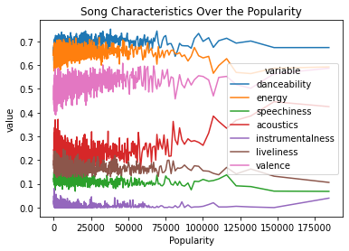

```python
#creating a line plot with popularity:x, musical features: y
ax = sns.lineplot(data=pd.melt(popSpotify, ['Popularity']), x='Popularity', y='value', hue='variable').set_title('Song Characteristics Over the Popularity')
```

This shows where the musical features lie for popularity. The musical features vary a lot when popularity is low meaning that tracks with more popularity have similar musical features to each other

# Hypothesis Testing

I want to see for sure if there is a correlation between the musical features of a song. When Hypothesis testing we will use the null hypothesis, which is that the variables do not correlate to Popularity. If we are given p values < 0.05, I will reject the null hypothesis.

To use logit, the target must have values between 0 and 1. I will create a new column that encodes the `Popularity` column into a value between 0 and 1 by using the formula curr_value - values' minimum / values' maximum. This will give us that relative encoding

```python
spotify1['pop_encoding'] = (spotify1['Popularity'] - spotify1['Popularity'].min())/spotify1['Popularity'].max()
spotify1.head()
```

|  | Country | Popularity | Artist | is_single | Artist_followers | Explicit | Release_date | danceability | energy | key | ... | tempo | duration_ms | time_signature | Genre_new | title_artist_album | year | num_Artist | num_Genre_new | num_Country | pop_encoding |
| --- | --- | --- | --- | --- | --- | --- | --- | --- | --- | --- | --- | --- | --- | --- | --- | --- | --- | --- | --- | --- | --- |
| 0 | Global | 31833.95 | Paulo Londra | 0 | 11427104.0 | 0 | 2018-11-05 | 0.767 | 0.709 | 1 | ... | 171.993 | 258639 | 4 | hip hop | adan y eva_Paulo Londra_Adan y Eva | 2018 | 18267 | 6 | 14 | 0.136175 |
| 1 | USA | 8.00 | Paulo Londra | 0 | 11427104.0 | 0 | 2018-11-05 | 0.767 | 0.709 | 1 | ... | 171.993 | 258639 | 4 | hip hop | adan y eva_Paulo Londra_Adan y Eva | 2018 | 18267 | 6 | 34 | 0.000031 |
| 2 | Argentina | 76924.40 | Paulo Londra | 0 | 11427104.0 | 0 | 2018-11-05 | 0.767 | 0.709 | 1 | ... | 171.993 | 258639 | 4 | hip hop | adan y eva_Paulo Londra_Adan y Eva | 2018 | 18267 | 6 | 0 | 0.329061 |
| 3 | Belgium | 849.60 | Paulo Londra | 0 | 11427104.0 | 0 | 2018-11-05 | 0.767 | 0.709 | 1 | ... | 171.993 | 258639 | 4 | hip hop | adan y eva_Paulo Londra_Adan y Eva | 2018 | 18267 | 6 | 3 | 0.003631 |
| 4 | Switzerland | 20739.10 | Paulo Londra | 0 | 11427104.0 | 0 | 2018-11-05 | 0.767 | 0.709 | 1 | ... | 171.993 | 258639 | 4 | hip hop | adan y eva_Paulo Londra_Adan y Eva | 2018 | 18267 | 6 | 30 | 0.088714 |

5 rows × 27 columns

Now that we have the encoding, we can run the stats model logit function which will get us a logistical regression of a dependent variable and variables that might determine the dependent variable. I make the dependent variable Popularity and the other variables are the musical features, and other mumerical variables that might have a correlation to Popularity

```python
reg = logit('pop_encoding ~ mode + danceability + tempo + energy + speechiness + acoustics + instrumentalness + liveliness + valence+Artist_followers+key+Explicit+time_signature+duration_ms+is_single+year',spotify1).fit()
reg.summary()
```

```
Optimization terminated successfully.
         Current function value: 0.033220
         Iterations 10
```

Logit Regression Results

| Dep. Variable: | pop_encoding | No. Observations: | 170573 |
| --- | --- | --- | --- |
| Model: | Logit | Df Residuals: | 170556 |
| Method: | MLE | Df Model: | 16 |
| Date: | Wed, 21 Jul 2021 | Pseudo R-squ.: | -6.813 |
| Time: | 14:36:53 | Log-Likelihood: | -5666.4 |
| converged: | True | LL-Null: | -725.23 |
| Covariance Type: | nonrobust | LLR p-value: | 1.000 |

|  | coef | std err | z | P>\|z\| | [0.025 | 0.975] |
| --- | --- | --- | --- | --- | --- | --- |
| Intercept | -59.1496 | 7.205 | -8.210 | 0.000 | -73.271 | -45.028 |
| mode | 0.0303 | 0.033 | 0.907 | 0.365 | -0.035 | 0.096 |
| danceability | 1.5925 | 0.146 | 10.913 | 0.000 | 1.307 | 1.879 |
| tempo | 0.0007 | 0.001 | 1.239 | 0.215 | -0.000 | 0.002 |
| energy | 0.2238 | 0.128 | 1.743 | 0.081 | -0.028 | 0.475 |
| speechiness | -0.8860 | 0.174 | -5.083 | 0.000 | -1.228 | -0.544 |
| acoustics | 0.4027 | 0.083 | 4.872 | 0.000 | 0.241 | 0.565 |
| instrumentalness | -1.5283 | 0.305 | -5.003 | 0.000 | -2.127 | -0.929 |
| liveliness | -0.4013 | 0.129 | -3.106 | 0.002 | -0.654 | -0.148 |
| valence | 0.3728 | 0.087 | 4.262 | 0.000 | 0.201 | 0.544 |
| Artist_followers | 1.404e-08 | 1.05e-09 | 13.399 | 0.000 | 1.2e-08 | 1.61e-08 |
| key | 0.0071 | 0.005 | 1.578 | 0.115 | -0.002 | 0.016 |
| Explicit | -0.3433 | 0.040 | -8.512 | 0.000 | -0.422 | -0.264 |
| time_signature | 0.1292 | 0.067 | 1.940 | 0.052 | -0.001 | 0.260 |
| duration_ms | 1.729e-06 | 3.01e-07 | 5.751 | 0.000 | 1.14e-06 | 2.32e-06 |
| is_single | -0.3274 | 0.034 | -9.603 | 0.000 | -0.394 | -0.261 |
| year | 0.0264 | 0.004 | 7.389 | 0.000 | 0.019 | 0.033 |

I will repeat logit model function without the variables we said were not significant, just to make sure the p values are still < 0.05. As you can see below, all pvalues < 0.05

```python
reg = logit('pop_encoding ~ danceability  + speechiness + acoustics + instrumentalness + liveliness + valence + Artist_followers + Explicit + duration_ms+is_single+year',spotify1).fit()
reg.summary()
```

```
Optimization terminated successfully.
         Current function value: 0.033211
         Iterations 10
```

Logit Regression Results

| Dep. Variable: | pop_encoding | No. Observations: | 170573 |
| --- | --- | --- | --- |
| Model: | Logit | Df Residuals: | 170561 |
| Method: | MLE | Df Model: | 11 |
| Date: | Wed, 21 Jul 2021 | Pseudo R-squ.: | -6.811 |
| Time: | 14:36:55 | Log-Likelihood: | -5664.8 |
| converged: | True | LL-Null: | -725.23 |
| Covariance Type: | nonrobust | LLR p-value: | 1.000 |

|  | coef | std err | z | P>\|z\| | [0.025 | 0.975] |
| --- | --- | --- | --- | --- | --- | --- |
| Intercept | -58.8816 | 7.168 | -8.214 | 0.000 | -72.931 | -44.832 |
| danceability | 1.5526 | 0.142 | 10.911 | 0.000 | 1.274 | 1.831 |
| speechiness | -0.8378 | 0.172 | -4.867 | 0.000 | -1.175 | -0.500 |
| acoustics | 0.3039 | 0.068 | 4.452 | 0.000 | 0.170 | 0.438 |
| instrumentalness | -1.5402 | 0.305 | -5.049 | 0.000 | -2.138 | -0.942 |
| liveliness | -0.3830 | 0.128 | -2.981 | 0.003 | -0.635 | -0.131 |
| valence | 0.4423 | 0.081 | 5.480 | 0.000 | 0.284 | 0.601 |
| Artist_followers | 1.373e-08 | 1.04e-09 | 13.230 | 0.000 | 1.17e-08 | 1.58e-08 |
| Explicit | -0.3452 | 0.040 | -8.570 | 0.000 | -0.424 | -0.266 |
| duration_ms | 1.751e-06 | 2.99e-07 | 5.852 | 0.000 | 1.16e-06 | 2.34e-06 |
| is_single | -0.3293 | 0.034 | -9.670 | 0.000 | -0.396 | -0.263 |
| year | 0.0266 | 0.004 | 7.502 | 0.000 | 0.020 | 0.034 |

I will show you a different approach using a linerar regression model this time, using OLS.

First we just get the numerical data of spotify1 so we can run the stats model on all the variables. Then we seperate out the dependent variable as the target and make all other variables the features, which will act as predictors

```python
numdf = spotify1._get_numeric_data()
target = numdf.iloc[:,[0]]
features = numdf.iloc[:,1:18]
print(target.head())
features.head()
```

```
   Popularity
0    31833.95
1        8.00
2    76924.40
3      849.60
4    20739.10
```

|  | is_single | Artist_followers | Explicit | danceability | energy | key | loudness | mode | speechiness | acoustics | instrumentalness | liveliness | valence | tempo | duration_ms | time_signature | year |
| --- | --- | --- | --- | --- | --- | --- | --- | --- | --- | --- | --- | --- | --- | --- | --- | --- | --- |
| 0 | 0 | 11427104.0 | 0 | 0.767 | 0.709 | 1 | -4.47 | 1 | 0.336 | 0.323 | 0.0 | 0.0676 | 0.72 | 171.993 | 258639 | 4 | 2018 |
| 1 | 0 | 11427104.0 | 0 | 0.767 | 0.709 | 1 | -4.47 | 1 | 0.336 | 0.323 | 0.0 | 0.0676 | 0.72 | 171.993 | 258639 | 4 | 2018 |
| 2 | 0 | 11427104.0 | 0 | 0.767 | 0.709 | 1 | -4.47 | 1 | 0.336 | 0.323 | 0.0 | 0.0676 | 0.72 | 171.993 | 258639 | 4 | 2018 |
| 3 | 0 | 11427104.0 | 0 | 0.767 | 0.709 | 1 | -4.47 | 1 | 0.336 | 0.323 | 0.0 | 0.0676 | 0.72 | 171.993 | 258639 | 4 | 2018 |
| 4 | 0 | 11427104.0 | 0 | 0.767 | 0.709 | 1 | -4.47 | 1 | 0.336 | 0.323 | 0.0 | 0.0676 | 0.72 | 171.993 | 258639 | 4 | 2018 |

```python
est = OLS(target, features.astype(float)).fit()
est.summary()
```

OLS Regression Results

| Dep. Variable: | Popularity | R-squared (uncentered): | 0.176 |
| --- | --- | --- | --- |
| Model: | OLS | Adj. R-squared (uncentered): | 0.175 |
| Method: | Least Squares | F-statistic: | 2136. |
| Date: | Wed, 21 Jul 2021 | Prob (F-statistic): | 0.00 |
| Time: | 14:36:55 | Log-Likelihood: | -1.8563e+06 |
| No. Observations: | 170573 | AIC: | 3.713e+06 |
| Df Residuals: | 170556 | BIC: | 3.713e+06 |
| Df Model: | 17 |  |  |
| Covariance Type: | nonrobust |  |  |

|  | coef | std err | t | P>\|t\| | [0.025 | 0.975] |
| --- | --- | --- | --- | --- | --- | --- |
| is_single | -1867.9217 | 65.228 | -28.637 | 0.000 | -1995.767 | -1740.077 |
| Artist_followers | 8.547e-05 | 2.46e-06 | 34.794 | 0.000 | 8.07e-05 | 9.03e-05 |
| Explicit | -1666.0206 | 75.341 | -22.113 | 0.000 | -1813.687 | -1518.354 |
| danceability | 7363.4266 | 260.744 | 28.240 | 0.000 | 6852.374 | 7874.479 |
| energy | -4661.8997 | 309.577 | -15.059 | 0.000 | -5268.663 | -4055.136 |
| key | 38.1473 | 8.712 | 4.379 | 0.000 | 21.072 | 55.222 |
| loudness | 553.7951 | 18.123 | 30.557 | 0.000 | 518.274 | 589.317 |
| mode | 14.6379 | 64.518 | 0.227 | 0.821 | -111.817 | 141.092 |
| speechiness | -1669.8624 | 301.180 | -5.544 | 0.000 | -2260.168 | -1079.557 |
| acoustics | 2263.9370 | 159.258 | 14.216 | 0.000 | 1951.794 | 2576.080 |
| instrumentalness | -1948.6369 | 358.441 | -5.436 | 0.000 | -2651.174 | -1246.100 |
| liveliness | -1780.4419 | 232.588 | -7.655 | 0.000 | -2236.308 | -1324.575 |
| valence | 1851.2500 | 166.604 | 11.112 | 0.000 | 1524.709 | 2177.791 |
| tempo | 0.9498 | 1.103 | 0.861 | 0.389 | -1.213 | 3.112 |
| duration_ms | 0.0086 | 0.001 | 13.524 | 0.000 | 0.007 | 0.010 |
| time_signature | 264.2225 | 102.034 | 2.590 | 0.010 | 64.237 | 464.208 |
| year | 1.9675 | 0.278 | 7.085 | 0.000 | 1.423 | 2.512 |

| Omnibus: | 163291.261 | Durbin-Watson: | 1.123 |
| --- | --- | --- | --- |
| Prob(Omnibus): | 0.000 | Jarque-Bera (JB): | 8229624.700 |
| Skew: | 4.690 | Prob(JB): | 0.00 |
| Kurtosis: | 35.710 | Cond. No. | 1.85e+08 |

Notes:  
[1] R² is computed without centering (uncentered) since the model does not contain a constant.  
[2] Standard Errors assume that the covariance matrix of the errors is correctly specified.  
[3] The condition number is large, 1.85e+08. This might indicate that there are  
strong multicollinearity or other numerical problems.

```python
features = features.drop(['mode','tempo','time_signature'], axis =1)
```

```python
est = OLS(target, features.astype(float)).fit()
est.summary()
```

OLS Regression Results

| Dep. Variable: | Popularity | R-squared (uncentered): | 0.176 |
| --- | --- | --- | --- |
| Model: | OLS | Adj. R-squared (uncentered): | 0.175 |
| Method: | Least Squares | F-statistic: | 2593. |
| Date: | Wed, 21 Jul 2021 | Prob (F-statistic): | 0.00 |
| Time: | 14:36:56 | Log-Likelihood: | -1.8563e+06 |
| No. Observations: | 170573 | AIC: | 3.713e+06 |
| Df Residuals: | 170559 | BIC: | 3.713e+06 |
| Df Model: | 14 |  |  |
| Covariance Type: | nonrobust |  |  |

|  | coef | std err | t | P>\|t\| | [0.025 | 0.975] |
| --- | --- | --- | --- | --- | --- | --- |
| is_single | -1865.6579 | 65.202 | -28.614 | 0.000 | -1993.452 | -1737.863 |
| Artist_followers | 8.541e-05 | 2.46e-06 | 34.783 | 0.000 | 8.06e-05 | 9.02e-05 |
| Explicit | -1666.9789 | 75.221 | -22.161 | 0.000 | -1814.410 | -1519.548 |
| danceability | 7408.8315 | 256.962 | 28.832 | 0.000 | 6905.191 | 7912.472 |
| energy | -4620.7223 | 308.801 | -14.963 | 0.000 | -5225.965 | -4015.479 |
| key | 37.7655 | 8.590 | 4.396 | 0.000 | 20.928 | 54.603 |
| loudness | 554.5191 | 18.116 | 30.610 | 0.000 | 519.013 | 590.025 |
| speechiness | -1624.8927 | 299.391 | -5.427 | 0.000 | -2211.693 | -1038.093 |
| acoustics | 2241.4975 | 158.890 | 14.107 | 0.000 | 1930.077 | 2552.918 |
| instrumentalness | -1979.4575 | 358.169 | -5.527 | 0.000 | -2681.461 | -1277.454 |
| liveliness | -1788.5252 | 232.487 | -7.693 | 0.000 | -2244.195 | -1332.855 |
| valence | 1857.8045 | 166.400 | 11.165 | 0.000 | 1531.665 | 2183.944 |
| duration_ms | 0.0087 | 0.001 | 13.559 | 0.000 | 0.007 | 0.010 |
| year | 2.5201 | 0.189 | 13.327 | 0.000 | 2.149 | 2.891 |

| Omnibus: | 163295.361 | Durbin-Watson: | 1.123 |
| --- | --- | --- | --- |
| Prob(Omnibus): | 0.000 | Jarque-Bera (JB): | 8229831.738 |
| Skew: | 4.690 | Prob(JB): | 0.00 |
| Kurtosis: | 35.710 | Cond. No. | 1.85e+08 |

Notes:  
[1] R² is computed without centering (uncentered) since the model does not contain a constant.  
[2] Standard Errors assume that the covariance matrix of the errors is correctly specified.  
[3] The condition number is large, 1.85e+08. This might indicate that there are  
strong multicollinearity or other numerical problems.

Now we only have significant p-values and can use these variables in our linear regression model.

## Machine Learning

Now we are trying to create a machine learning component that can successfully predict Popularity from the cariables we deemed significant above. I will be using linear regression model since our target variable is continous meaning that it is a range of values as opposed to a binary variable that contains only 2 values.

We will standardize data across all features along and axis.

```python
#Standardizing numerical data
features = preprocessing.scale(features)
```

```python
X, y = features, target
X.shape, y.shape
```

```
((170573, 14), (170573, 1))
```

The train-test split procedure is used to estimate the performance of machine learning algorithms when they are used to make predictions on data not used to train the model. This means we will take our data and split it into training groups and testing groups. The training group will be used to calculate the linear regression model. The test group will be used to find the accuracy of that model

```python
#spliting the data using train_test_split
X_train, X_test, y_train, y_test = train_test_split(X, y, test_size=0.4, random_state=0)
```

```python
#finding the linear regression only on the training data
lin_reg = LinearRegression().fit(X_train, y_train)
```

```python
predictions = lin_reg.predict(X_test)
```

```python
# This tests how well the X test data would predict the Y test result
lin_reg.score(X_test, y_test)
```

```
0.03633083515422697
```

```python
np.sqrt(metrics.mean_squared_error(y_test, predictions))
```

```
12742.251155894332
```

We will use a 10 fold Cross Validation. K-fold cross validation is a procedure used to estimate the skill of the model on new data. This means we split the data into 10 groups, evaluate the the score of how well each group predicted the target value.

```python
scores = cross_val_score(lin_reg, X, y, cv=10)
scores
```

```
array([ 0.03246292, -0.00101037,  0.01516226,  0.0418543 ,  0.02921183,
       -0.10102671, -0.06821115, -0.05653591, -0.01907983, -0.01411062])
```

```python
print("Accuracy of SVM Model with Cross Validation is:",scores.mean() * 100)
```

```
Accuracy of SVM Model with Cross Validation is: -1.412832827831484
```

As you can see from the scores we do not have a very accurate model. I am not sure what the problem is since all the p values were significant